# EDS 240: Assignment #2 Part 2

Author

Karol Paya

Published

January 31, 2025

# Background

**monthly_water_shortage_outlook**

The primary function of the AWSDA is to motivate planning processes for water shortages. These data represent forecasts specific to the urban supplier and a snapshot in time based on the conditions when the supplier completed the plan. These data are expected to change as conditions change and water shortage plans are updated.

Source: Department of Water Resources (DWR) Water Use Efficiency portal

Import libraries

**Click to view code**

```r
# Load libraries
library(here)
library(ggplot2)
library(dplyr)
library(janitor)
library(ggridges)
library(tidycensus)
library(tidyverse)
```

Import data

**Click to view code**

```r
# Read data
demands_2022 <- read.delim(here('data/wsda_table2_2022_demands.xls'), sep = "\t")
supply_2022 <- read.delim(here('data/wsda_table3_2022_supply.xls'), sep = "\t")
demands_2023 <- read.delim(here('data/wsda_table2_2023_demands.xls'), sep = "\t")
supply_2023 <- read.delim(here('data/wsda_table3_2023_supply.xls'), sep = "\t")
demands_2024 <- read.delim(here('data/wsda_table2_2024_demands.xls'), sep = "\t")
supply_2024 <- read.delim(here('data/wsda_table3_2024_supply.xls'), sep = "\t")
```

Wrangle data

**Click to view code**

```r
# Function 1: Converts to Pivot Longer
summarize_table <- function(df, county) {
  # Extract the type (either "demand" or "supply") from the dataframe name
  type <- str_extract(deparse(substitute(df)), "(demands|supply)")
  # Create the corresponding column name
  total_column_name <- paste0("total_", type)

  df_subset_long <- df %>%
    filter(WATER_SUPPLIER_NAME == county, POTABLE_NONPOTABLE == 'potable') %>%
    pivot_longer(
      cols = ends_with("DEMANDS"),  # Select columns that end with "DEMANDS"
      names_to = "Month",                  # Create a new column for the month
      values_to = type,                    # Create a new column for the demand/supply values
      names_transform = list(Month = toupper)  # Keep month names in uppercase
    )
  # Summarize the data by month
  df_subset_long_month <- df_subset_long %>%
    group_by(Month) %>%           # Group by the Month column
    summarize(!!total_column_name := sum(!!sym(type), na.rm = TRUE))  # Sum the values for each month

  return(df_subset_long_month)
}
```

```r
# Function 2: process and merge data for all years (2022 to 2024)
process_year_data <- function(start_year, end_year , county) {
  # Initialize an empty list to store the data frames for each year
  final_data <- list()

  # Loop through the years
  for (year in start_year:end_year) {
    # Dynamically load the demand and supply data for each year
    demands_file <- here(paste0('data/wsda_table2_', year, '_demands.xls'))
    supply_file <- here(paste0('data/wsda_table3_', year, '_supply.xls'))

    demands_df <- read.delim(demands_file, sep = "\t")
    supply_df <- read.delim(supply_file, sep = "\t")

    # Summarize the demands and supply for the current year
    demands_summary <- summarize_table(demands_df, county) %>%
      mutate(Year = year)
    supply_summary <- summarize_table(supply_df, county) %>%
      mutate(Year = year)

    # Merge demands and supply summaries
    merged_summary <- left_join(demands_summary, supply_summary, by = 'Month')

    # Remove the redundant Year column (Year.x or Year.y)
    merged_summary <- merged_summary %>%
      select(Month, total_demands, total_supply, Year = Year.x)

    # Drop the '_DEMAND' part of the Month name and add the corresponding month number
    merged_summary <- merged_summary %>%
      mutate(
        Month = str_remove(Month, "_DEMANDS"),  # Remove '_DEMAND' suffix
        Month = str_to_title(Month),
        Month_number = match(Month, month.name), # Map month names to month numbers
        Date = as.Date(paste(Year, Month_number, "01", sep = "-"), format = "%Y-%m-%d") #Create a Date object
      )
    # Append the merged data to the final list
    final_data[[as.character(year)]] <- merged_summary
  }

  # Combine all year-wise data into one final data frame
  final_table <- bind_rows(final_data)

  return(final_table)
}
```

Run function

```r
# Assign variables
start_year=2022
end_year= 2024
county='Alameda County Water District'

# Call the function
final_results <- process_year_data(start_year, end_year, county)
```

# Plot 1

**Click to view code**

```r
plot1 <- ggplot(final_results, aes(x = Date)) +
  geom_line(aes(y = total_demands, color = "Demand"), size = 1) +  # Line for total_demand
  geom_line(aes(y = total_supply, color = "Supply"), size = 1) +  # Line for total_supply
  geom_point(aes(y = total_demands, color = "Demand"), size = 2) +  # Add points for demand
  geom_point(aes(y = total_supply, color = "Supply"), size = 2) +  # Add points for supply
  labs(
    title = "Alameda County: Comparison of Water Supply and Demand",
    x = "Date",
    y = "Water Volume (Acre-Foot)",
    color = "Type"  # Label for the color legend
  ) +
  scale_x_date(date_labels = "%b %Y", date_breaks = "4 months") +  # Format x-axis as Month Year
  scale_color_manual(values = c("Demand" = "cyan3", "Supply" = "firebrick")) +  # Custom colors for Demand and Supply

  theme(
    plot.title = element_text(size = 16, face = "bold", hjust = 0.5),
    plot.subtitle = element_text(hjust = 0.5),
    axis.title = element_text(size = 8),
    axis.text.x = element_text(angle = 45, size = 8, hjust = 1),
    axis.title.x = element_text(size = 10, face = "bold"),
    axis.title.y = element_text(size = 10, face = "bold"),
    legend.position = "bottom" , # Position the legend at the bottom
    borderaxis.line = element_line(color = "black", size = 1),  # Add axis lines
    panel.grid.minor = element_blank(),
    plot.background = element_rect(color = "black", size = 1)  # Background with

  )
```

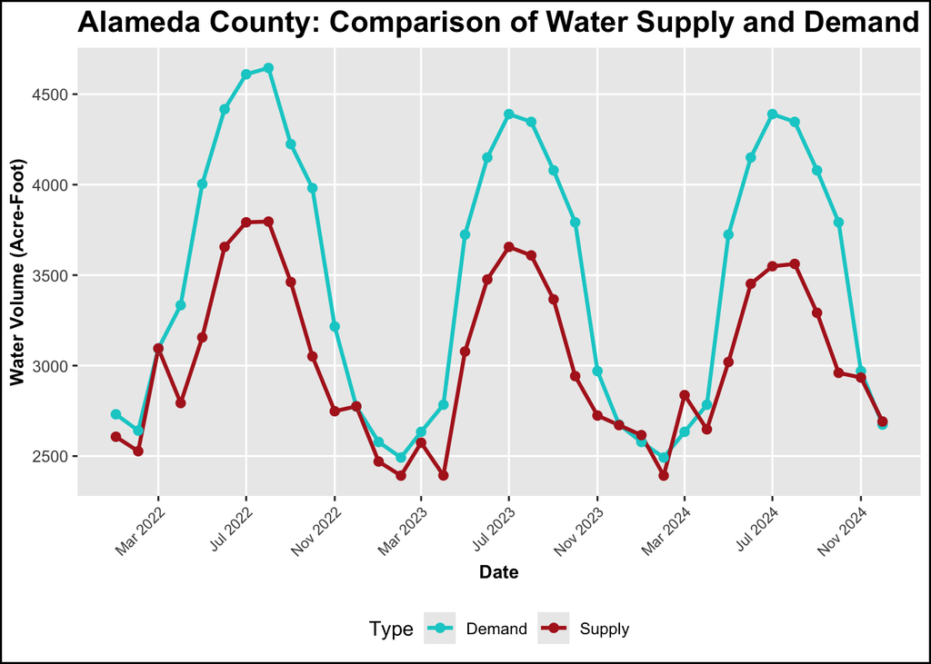

```r
# Display plot
plot1
```

# Plot 2

**Click to view code**

```r
# Import dataset
supply_2024 <- read.delim(here('data/wsda_table3_2024_supply.xls'), sep = "\t")

# Select county, group by source of supply and sum all demands
df2 <- supply_2024 %>%
  filter(WATER_SUPPLIER_NAME == 'Alameda County Water District', POTABLE_NONPOTABLE == 'potable') %>%
  # Select only columns that end with '_DEMANDS' and are numeric
  mutate(total_supply = rowSums(select(., ends_with("_DEMANDS")), na.rm = TRUE)) %>%
  group_by(SUPPLIES) %>%
  summarise(total_supply = sum(total_supply, na.rm = TRUE))  # Sum all demands

# Create the bar plot
plot2 <- ggplot(df2, aes(x = reorder(SUPPLIES, total_supply), y = total_supply, fill = SUPPLIES)) +
  geom_bar(stat = "identity", show.legend = FALSE) +
  labs(
    title = "Sources of Water Supply in Alameda County (2024)",
    x = "Source of Supply",
    y = "Total Supply (Acre-Foot)"
  ) +
  theme_minimal() +
  theme(
    axis.text.x = element_text(angle = 45, hjust = 1),  # Rotate x-axis labels for readability
    plot.title = element_text(hjust = 0.5)  # Center the title
  )
```

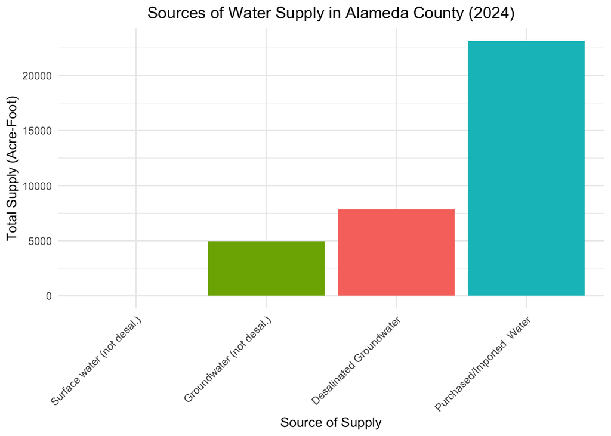

```r
# Print the plot
print(plot2)
```

# Plot 3

**Click to view code**

```r
Alameda<-final_results %>%
  mutate(diff=total_supply - total_demands)%>%
  filter(Year==2024)

Bakersfield<- process_year_data(start_year, end_year, "Bakersfield  City Of")%>%
  mutate(diff=total_supply - total_demands)%>%
  filter(Year==2024)

Goleta<-process_year_data(start_year, end_year, "Goleta Water District")%>%
  mutate(diff=total_supply - total_demands)%>%
  filter(Year==2024)

# Combine the three data frames into one
combined_data2 <- bind_rows(
  Alameda %>% mutate(County = "Alameda"),
  Bakersfield %>% mutate(County = "Bakersfield"),
  Goleta %>% mutate(County = "Goleta")
)


# Create the horizontal bar plot with facet_wrap
plot3<-ggplot(combined_data2, aes(x = diff, y = Month, fill = County)) +
  geom_bar(stat = "identity", show.legend = FALSE) +  # Horizontal bar plot
  facet_wrap(~ County, scales = "free_y") +  # Facet by County with free y scales
  labs(
    title = "Monthly Demand vs. Supply Difference in California Counties (2024)",
    x = "Difference (Supply - Demand) (Acre-Feet)",
    y = "Month"
  ) +
  scale_fill_manual(values = c("Alameda" = "deepskyblue4", "Camrosa" = "gold1", "Goleta" = "darkseagreen1")) +  # Custom fill colors
  theme_minimal() +
  theme(
    plot.title = element_text(hjust = 0.5),  # Center the title
    axis.title.x = element_text(size = 12),  # Label size adjustments
    axis.title.y = element_text(size = 12),
    axis.text = element_text(size = 10),
    strip.text = element_text(size = 14),  # Bigger facet labels
    panel.spacing = unit(1, "lines")  # Space between panels
  )
```

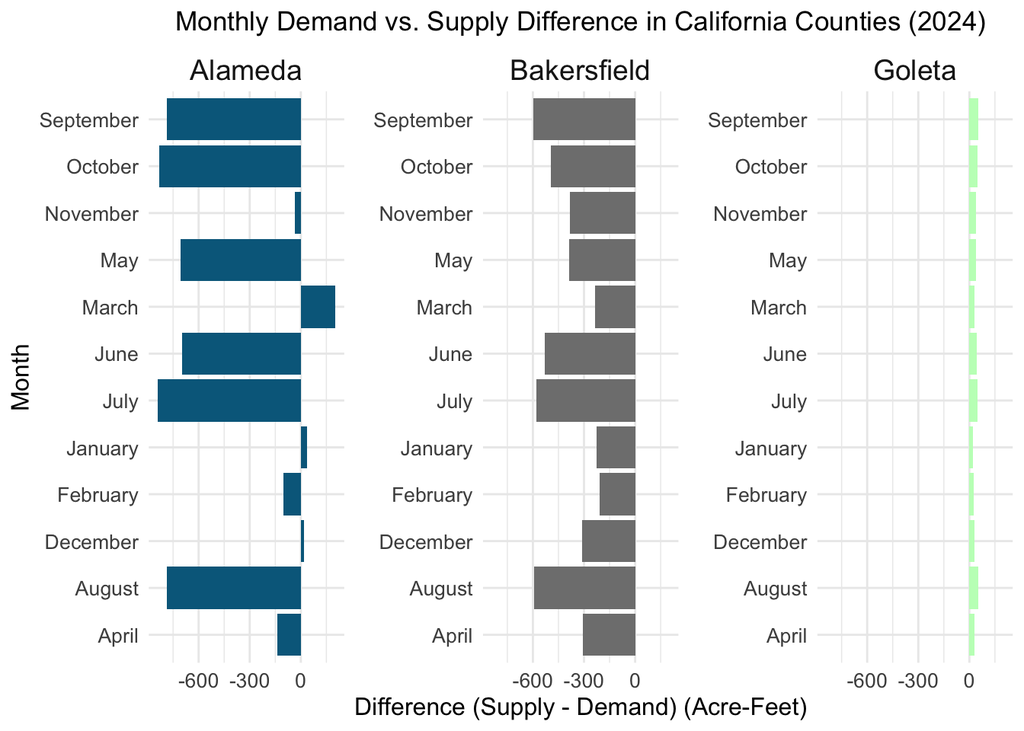

```r
# Display plot
plot3
```

# 2c. Answer questions

**1. What have you learned about your data? Have any potentially interesting patterns emerged?**

The dataset requires a lot of data wrangling, found several inconsistencies and missing values. These issues make it challenging to draw any conclusions. Need to inquire about the negative values in the supply - demand difference, could these negative values indicate a drought situation?

**2. In HW #1, you outlined some questions that you wanted to answer using these data. Have you made any strides towards answering those questions? If yes, how so? If no, what next steps do you need to take (e.g. I need to create X plot type, I still need to track down Y data, I need to restructure existing data so that you can visualize it in Z ways, etc.)?**

I wanted to explore California’s water crisis, focusing on vulnerability and risk across counties. After conducting this analysis, I feel I’ve made some strides in this direction. By analyzing supply and demand data at the county level, I’ve identified some discrepancies between supply and demand across different regions, which may indicate vulnerability. I’ve started to look for months where demand > supply, potentially highlighting areas at greater risk of water scarcity.

**3. What challenges do you foresee encountering with your data? These can be data wrangling and / or visualization challenges.**

Data wrangling, the data is not in a format that is easily compatible with data science tools, so a significant amount of cleaning and manipulation is required to prepare it for analysis and visualization.